# Data Mobilisation from GBIF to the EBV Data Portal for IAS of Union Concern

Notebook 2 - Data exploration of the IAS occurrence cube

Lina Estupinan-Suarez, Emmanuel Oceguera, Miguel Fernandez

German Centre for Integrative Biodiversity Research (iDiv)  
lina.estupinans@idiv.de

2024-08-23

[figure not shown]

### Introduction

In this notebook we explore the occurrence data of invasive alien species (IAS) of union concern available in [GBIF—the Global Biodiversity Information Facility—](https://www.gbif.org/) until mid August 2024. To do this, an IAS occurrence cube was previously created using the [occurrence cube software](https://techdocs.gbif.org/en/data-use/data-cubes) developed by GBIF under the [Biodiversity Building Blocks for Policy (B3)](https://b-cubed.eu/) project. Details of the data query in GBIF are available at [DOI 10.15468/dl.gxk3vh](https://doi.org/10.15468/dl.gxk3vh). The cube generation script is also part of this repository.

*Note: This series of notebooks is part of the results of Task 3.3 of the [Biodiversity Building Blocks for Policy](https://b-cubed.eu/) project funded by the European Union’s Horizon Europe Research and Innovation Programme (ID No 101059592). Additional notebooks exploring the results and calculating simple metrics are also available in the same repository.*

### Load library and input data

```r
rm(list=ls())
gc()
```

```
         used (Mb) gc trigger (Mb) max used (Mb)
Ncells 531291 28.4    1188987 63.5   657974 35.2
Vcells 970474  7.5    8388608 64.0  1768271 13.5
```

```r
# load requiered libraries
library(here)
library(ggplot2)
library(dplyr)
library(lubridate)
library(b3gbi)
library(stringr)
```

After loading the necessary libraries, we load the occurrence cube of IAS obtained previously through the GBIF API.

```r
# Load IAS occurrence cube obtained through GBIF

# File name from the JSON query
occcube <- "0077925-240506114902167"

# Load occurrence cube using b3gbi
cin <- process_cube(here(paste0("output/datacubes/csv/ias/", occcube,".csv")))

# Load species taxonomy resulting from the match between the updates IAS list of union concern and the GBIF backbone taxonomy
tax <- read.csv(here("input/data/ias/taxonomy/List87IAS_EU_match_gbif_synonyms.csv"))
```

As some of the scientific names of the IAS of union are considered synonyms by the GBIF backbone taxonomy, we will use the `acceptedUsageKey` for the synonyms and the `key` for the accepted scientific names. To do this, we will fill in the `acceptedUsageKey` column with the `key` for accepted names, and keep the `acceptedUsageKey` for synonyms. Thus, the accepted keys for all species in the list will appear in the `acceptedUsageKey` column.

```r
# Merge in one column `key` of accepted names and `acceptedUsageKey` of synonyms
tax <- tax %>%
  mutate(acceptedUsageKey = coalesce(acceptedUsageKey, key))

# Write CSV with `acceptedUsageKey` for all species to be used in the JSON query
write.csv(tax, here("input/data/ias/taxonomy/List87IAS_EU_match_gbif_synonyms_acceptedUsageKeys.csv"), row.names = FALSE)
```

### Data Analysis

#### Calculate Total Number of Occurrence

```r
cdata <- cin[["data"]]
# rename columns
colnames(cdata)[colnames(cdata) == "order"] <- "order_"
colnames(cdata)[colnames(cdata) == "taxonKey"] <- "acceptedUsageKey"

# Aggregate occurrences at species level
cag <- cdata %>%
  group_by(acceptedUsageKey) %>%
  summarize(totalOcc = sum(obs))

 # Sort in ascending order
cag <- cag[order(cag$totalOcc), ]
```

```r
# Rename columns for joining occurence cube with GBIF Backbone taxonomy
xout <- merge(x=cag, y=tax[,c("scientificName", "acceptedUsageKey", "kingdom", "phylum", "class", "order", "family")], by="acceptedUsageKey")
xout <- xout[order(xout$totalOcc), ]

write.csv(xout, here("output/summary_data/csv/ias/summary_ias_totalOccurrences.csv"), quote = FALSE, row.names = FALSE)
```

#### Identify IAS without Records in GBIF

```r
# # Find what species have no records in GBIF
noocc <- anti_join(tax, cag, by = "acceptedUsageKey")
write.csv(noocc, here("output/summary_data/csv/ias/ias_noOccurrences.csv"), quote = FALSE, row.names = FALSE)
print(noocc)
```

```
   occurrenceId
1            NA
2            NA
3            NA
4            NA
5            NA
6            NA
7            NA
8            NA
9            NA
10           NA
                                                                           verbatimScientificName
1                                                                     Channa argus (Cantor, 1842)
2                                  Cortaderia selloana subsp. jubata (Lemoine) Testoni & Villamil
3                                                              Limnoperna fortunei (Dunker, 1857)
```

[output cut: 73 more lines]

### Data Exploration

We will explore data available since 1900. To do this, first we split the ‘yearMonth’ column into ‘year’ and ‘month’.

```r
# Convert date from character to numeric
todates <- as.data.frame(str_split(cdata$yearMonth, "-", simplify = TRUE))
colnames(todates) <- c("year", "month")

# Add year and month columns separate to the initial data
cdata$year <- todates$year
cdata$month <- todates$month

# Filter data starting from 1900
cdata2 <- cdata %>%
  filter(year > 1900)

# Group data by year
cag_year <- cdata2 %>%
    group_by(year) %>%
  summarize(totalOcc = sum(obs))

# Group data by month
cag_month <- cdata %>%
    group_by(month) %>%
  summarize(totalOcc = sum(obs))
```

In the following code chunk we plot the GBIF occurrences available since 1900 for the IAS of union concern.

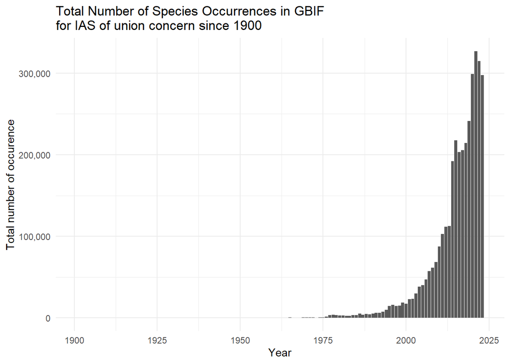

```r
theme_update(plot.title = element_text(hjust = 0.5))
ggplot(cag_year, aes(x = as.numeric(year), y = totalOcc)) +
  geom_bar(stat = "identity") +
  scale_y_continuous(label = scales::label_comma(accuracy = 1)) +
  ggtitle("Total Number of Species Occurrences in GBIF \nfor IAS of union concern since 1900") +
  labs(x = "Year",
       y = "Total number of occurence") +
       guides(color = guide_legend(override.aes = list(size = 5))) +
  theme(plot.title = element_text(hjust = 0.5)) +
  theme_minimal()
```

Now we plot the all GBIF occurrences per month for the IAS of union concern.

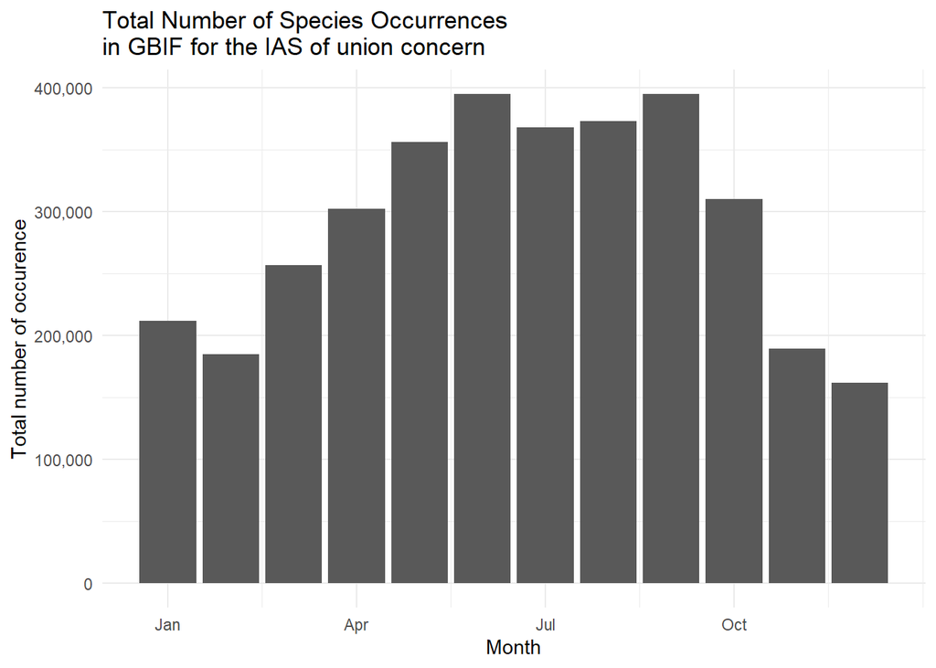

```r
ggplot(cag_month, aes(x = as.numeric(month), y = totalOcc)) +
  geom_bar(stat = "identity") +
  scale_x_continuous(breaks = c(1,4,7,10), labels = c("Jan", "Apr", "Jul", "Oct")) +
  scale_y_continuous(label = scales::label_comma(accuracy = 1)) +
  ggtitle("Total Number of Species Occurrences \nin GBIF for the IAS of union concern") +
  labs(x = "Month",
       y = "Total number of occurence") +
       guides(color = guide_legend(override.aes = list(size = 5))) +
  theme_minimal()
```

```r
# Aggregate occurrences at species level
cag_sp <- cdata %>%
  group_by(acceptedUsageKey) %>%
  summarize(totalOcc = sum(obs))

# Select the five species with more records
cag_sel <- cag_sp[(dim(cag_sp)[1]-5):dim(cag_sp)[1],]

# Subset data set
cag_top5 <- cdata %>%
  inner_join(cag_sel[,c("acceptedUsageKey")], by = "acceptedUsageKey") %>%
  filter(year > 1990)

# Aggregate occurrences by year
cag_top5year <- cag_top5 %>%
  group_by(year, scientificName) %>%
  summarize(totalOcc = sum(obs), scientificName = first(scientificName))
```

[figure not shown]

```r
ggplot(cag_top5year, aes(x = as.numeric(year), y = totalOcc, color = scientificName, name = "Species")) +
  geom_line(linewidth = 1.6) +
  guides(color=guide_legend(ncol=1, title = "Species")) +
  ggtitle("Annual species occurrences since 1990 for the top five \nGBIF occurrence of the IAS of union concern") +
  labs(x = "Year",
       y = "Total number of occurence") +
  theme_minimal()
```